# Website Presentation

December 5, 2025

Phu Vo

## Introduction

**Quantifying Emily Dickinson’s Poetry**

- Full-text analysis of all poems from the DickinsonPoems R package
- Try and identify characteristics of Dickinson’s writing through regex & text processing.
- Focuses:
  - Vocabulary Patterns
  - Punctuation Behavior
  - Motifs (ex: death, nature, time)
  - Personal language (“my ___, I”)
- Aim to study how Dickinson writes across her entire body of work, rather than attempt to interpret individual poems.

## Original Analysis

### Version 1 Overview

- Used regular expressions to extract:
  - Death-related vocabulary (appears in text 4, 8, 9)
  - Four-digit, year like numbers
  - Words following “my” through lookbehind (soul, reach)
- Plotted:
  - Most frequent word counts
  - Relationship between poem length and punctuation count

### Original Code

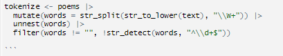

### Limitations

- Raw frequency reflected common English usage rather than poetic style
- Contractions created fragmented words (e.g., isolated letters from “don’t”)
- Stop words dominated results, masking meaningful language patterns

The original analysis measured language structure rather than poetic meaning.

### Original Output

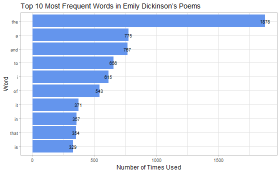

## New Analysis

### Refinements in Version 2

- Cleaned text by removing:
  - Contractions
  - Apostrophes and possessive endings
  - One-letter fragments (ex: s after it’s, or t after don’t)
- Removed common pronouns, articles, and auxiliary verbs (stop words)
- Try and limit the words down to limited, meaningful text

### Updated Code

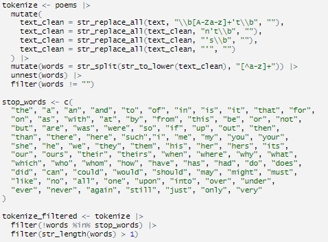

### Key Findings

The most frequent words after filtering out all stop words involve measurement, especially of time and space:

- little
- will
- till
- away
- day
- life

These words emphasize fate (the inevitable), and significance (what matters).

### New Output

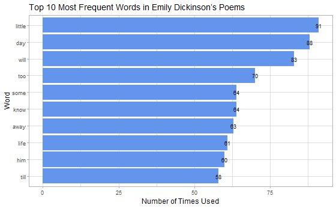

## Semantic Interpretation

### Poetic Functions of Common Words

| Word | Function |
| --- | --- |
| little | Attention to size and length, precision, measured perception |
| day / life | Boundaries, duration, temporal framing |
| till / will | Anticipation, incompleteness, inevitability, deferred action |
| away | Distance, separation, loss, withdrawal |

Dickinson’s writing is empowered not through elaborate vocabulary, but through framing and restricted language. She builds meaning by holding back, delaying, or measuring experience.

## Punctuation Analysis

### Poem Length and Punctuation Frequency

Observations: - Longer poems generally contain more punctuation - However, there is significant variation beyond the predicted trend

Punctuation functions stylistically rather than mechanically. In many poems, punctuation marks (particularly dashes) serve as rhythmic and expressive devices that shape hesitation, emphasis, and tone.

### Original Code

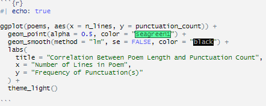

### Output

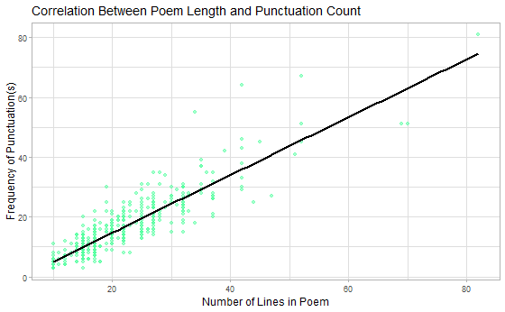

## Future Work

Possible extensions of this analysis include:

- Separate classification of em dashes distinct from other punctuation
- Topic modeling to group poems by thematic patterns such as death, nature, faith, or memory
- Sentiment analysis to measure emotional levels in the poems.
- Temporal comparison of early and late poems to detect stylistic changes/evolution.